# Group Project: Milestone 3

Iowa Liquor Sales 2015

October 22, 2018

## Introduction

For the project we decided to look at the “Iowa Liquor Sales” dataset. This data set has 12 million entries that includes information such as what product was sold, where it was store it was sold, where the store was located, cost of the product, when the product was sold, and so forth. With this information, we can help liquor-selling businesses determine which products are preferred to be bought by customers on which days and at what times. We are also assuming that all stores have a Sunday Sales Privilege and can sell and serve products on Sunday.

With all that in mind these are the questions we are hoping to answer.

. Which cities sell the most/least alcohol

. What is the correlation between bottles sold and time of the year?

. What date of the year sells the most/least alcohol?

. How much profit do prodcut bring in?

. What products sell the most/least bottles?

. Which months sell the most bottles?

. How many bottles are likely to be sold in the future?

As a brief bit of background, Iowa is an alcohol beverage control state, meaning that the state maintains a monopoly on wholesaling of alcohol throughout the State. Effectively, private retailers must purchase their alcohol from the state before selling it to individual consumers. With the dataset that we have we would like to use it’s information to help private retailers to be more informed about consumer decisions and its results. With this knowledge, private retailers will be able to better stock their shelves during the appropriate season, from the right vendors. This is an important business problem to analyze because it can help improve liquor sales for the whole state of Iowa, and make products cheaper for the consumer.

## Data Source and Collection

The dataset was downloaded from kaggle.com and was gathered by the Iowa Department of Commerce. In Iowa every store that sells alcohol in bottled form must hold a Class “E” liqour license and every sale must be logged in the Commerce department system. This data is a fairly complete representation of alcohol sales in the state of Iowa from the years 2011 to 2017. Although we are only going to be using the year 2015 for our data analysis.

Here is a link to the dataset: https://www.kaggle.com/residentmario/iowa-liquor-sales

## R Code Milestone 2

## _________________________________________________________________

# Clean Environment

```r
rm(list=ls())
```

# Load Packages

```r
library(magrittr)
library(dplyr)
library(tidyr)
```

```r
library(ggplot2)
library(stargazer)
library(caret)
library(neuralnet)
library(pscl)
```

# Call Data

```r
df<-read.csv(file="Iowa_Liquor_Sales.csv",header=TRUE)
#df<-read.csv(file="liq_test.csv",header=TRUE)
head(df)
```

```
##   Invoice.Item.Number       Date Store.Number
## 1        S29198800001 11/20/2015         2191
## 2        S29195400002 11/21/2015         2205
## 3        S29050300001 11/16/2015         3549
## 4        S28867700001 11/04/2015         2513
## 5        S29050800001 11/17/2015         3942
## 6        S28869200001 11/11/2015         3650
##                         Store.Name             Address         City
## 1                   Keokuk Spirits           1013 MAIN       KEOKUK
## 2           Ding's Honk And Holler    900 E WASHINGTON     CLARINDA
## 3             Quicker Liquor Store        1414 48TH ST FORT MADISON
## 4 Hy-Vee Food Store #2 / Iowa City      812  S 1ST AVE    IOWA CITY
## 5                 Twin Town Liquor 104 HIGHWAY 30 WEST       TOLEDO
## 6       Spirits, Stogies and Stuff  118 South Main St.     HOLSTEIN
##   Zip.Code                                              Store.Location
```

[output cut: 41 more lines]

# Remove all rows that are not the year 2015

```r
df <- df[!grepl("2017", df$Date),]
df <- df[!grepl("2016", df$Date),]
df <- df[!grepl("2014", df$Date),]
df <- df[!grepl("2013", df$Date),]
df <- df[!grepl("2012", df$Date),]
df <- df[!grepl("2011", df$Date),]
```

# Check if there are values less than 1 in important columns

We are specifically looking to see if there are values less than 1 in the columns Bottles.Sold, Volume.Sold..Liters., and Volume.Sold..Gallons.

```r
names(which(sapply(df, function(x) any(is.numeric(x)<1))))
```

```
##  [1] "Invoice.Item.Number" "Date"                "Store.Name"
##  [4] "Address"             "City"                "Zip.Code"
##  [7] "Store.Location"      "County"              "Category.Name"
## [10] "Vendor.Name"         "Item.Description"    "State.Bottle.Cost"
## [13] "State.Bottle.Retail" "Sale..Dollars."
```

# Look for and remove Unwanted Columns

```r
names(which(sapply(df, function(x) any(is.na(x)))))
```

```
## [1] "County.Number" "Category"
```

```r
df <- within(df, rm(Category, Category.Name, County.Number))
head(df)
```

```
##   Invoice.Item.Number       Date Store.Number
## 1        S29198800001 11/20/2015         2191
## 2        S29195400002 11/21/2015         2205
## 3        S29050300001 11/16/2015         3549
## 4        S28867700001 11/04/2015         2513
## 5        S29050800001 11/17/2015         3942
## 6        S28869200001 11/11/2015         3650
##                         Store.Name             Address         City
## 1                   Keokuk Spirits           1013 MAIN       KEOKUK
## 2           Ding's Honk And Holler    900 E WASHINGTON     CLARINDA
## 3             Quicker Liquor Store        1414 48TH ST FORT MADISON
## 4 Hy-Vee Food Store #2 / Iowa City      812  S 1ST AVE    IOWA CITY
## 5                 Twin Town Liquor 104 HIGHWAY 30 WEST       TOLEDO
## 6       Spirits, Stogies and Stuff  118 South Main St.     HOLSTEIN
##   Zip.Code                                              Store.Location
```

[output cut: 34 more lines]

# Extract months from date

```r
df$Month <- format(as.Date(df$Date, format="%m/%d/%Y"),"%m")
```

# Change Data types

```r
df$Sale..Dollars. = as.numeric(gsub("[\\$,]", "", df$Sale..Dollars.))
```

# Summary Statistics

```r
summary(df)
```

```
##    Invoice.Item.Number          Date          Store.Number
##  S23201600001:      1   12/01/2015:  15588   Min.   :2106
##  S23201600002:      1   11/30/2015:  14686   1st Qu.:2603
##  S23201600003:      1   12/28/2015:  14603   Median :3713
##  S23201600004:      1   12/29/2015:  14077   Mean   :3579
##  S23201600005:      1   06/01/2015:  14051   3rd Qu.:4357
##  S23201600006:      1   12/02/2015:  13979   Max.   :9023
##  (Other)     :2184477   (Other)   :2097499
##                                Store.Name
##  Hy-Vee #3 / BDI / Des Moines       :  19508
##  Central City 2                     :  18212
##  Hy-Vee Wine and Spirits / Iowa City:  14273
##  Hy-Vee Food Store / Cedar Falls    :  13407
##  Hy-Vee Food Store #1 / Mason City  :  13098
##  Central City Liquor, Inc.          :  12866
##  (Other)                            :2093119
##                Address                    City            Zip.Code
##  3221 SE 14TH ST   :  25822   DES MOINES    : 190254   50010  :  56878
##  1501 MICHIGAN AVE :  18212   CEDAR RAPIDS  : 150341   52402  :  56552
##  1720 WATERFRONT DR:  14273   DAVENPORT     :  93158   52240  :  50048
##  6301 UNIVERSITY   :  13407   WATERLOO      :  67857   50613  :  41728
##  2400 4TH ST SW    :  13098   IOWA CITY     :  65319   51501  :  37934
##  1460 2ND AVE      :  12866   COUNCIL BLUFFS:  65138   52001  :  37776
##  (Other)           :2086805   (Other)       :1552416   (Other):1903567
##                                                     Store.Location
##  3221 SE 14TH ST\nDES MOINES 50320\n(41.554101, -93.596754)  :  19508
##  1501 MICHIGAN AVE\nDES MOINES 50314\n(41.605561, -93.613738):  18212
##  1720 WATERFRONT DR\nIOWA CITY 52240\n(41.64277, -91.530467) :  14273
##  6301 UNIVERSITY\nCEDAR FALLS 50613\n(42.512771, -92.433344) :  13407
##  2400 4TH ST SW\nMASON CITY 50401\n(43.148446, -93.236556)   :  13098
##  1460 2ND AVE\nDES MOINES 50314\n(41.60566, -93.619787)      :  12866
##  (Other)                                                     :2093119
##            County        Vendor.Number
##  Polk         : 394660   Min.   : 10.0
##  Linn         : 187851   1st Qu.:115.0
##  Scott        : 134741   Median :260.0
##  Black Hawk   : 121019   Mean   :255.9
##  Johnson      : 108835   3rd Qu.:380.0
##  Pottawattamie:  73900   Max.   :978.0
##  (Other)      :1163477
```

[output cut: 25 more lines]

```
##  Min.   :     1.34   Min.   :   0.00      Min.   :   0.000
##  1st Qu.:    30.72   1st Qu.:   1.50      1st Qu.:   0.400
##  Median :    70.56   Median :   5.25      Median :   1.390
##  Mean   :   130.16   Mean   :   8.98      Mean   :   2.373
##  3rd Qu.:   135.36   3rd Qu.:  10.50      3rd Qu.:   2.770
##  Max.   :106326.00   Max.   :3960.00      Max.   :1046.120
##
##     Month
##  Length:2184483
##  Class :character
##  Mode  :character
##
##
##
##
```

## _________________________________________________________________

# Total spent over the year(in millions)

```r
sum(df$Sale..Dollars./1000000)
```

```
## [1] 284.3286
```

## _________________________________________________________________

# Total volume over the year in liters/gallons

# Liters(in millions)

```r
sum(df$Volume.Sold..Liters./1000000)
```

```
## [1] 19.6177
```

# Gallons(in millions)

```r
sum(df$Volume.Sold..Gallons./1000000)
```

```
## [1] 5.1829
```

## _________________________________________________________________

# What date sold the most

```r
dateSale <- df %>%
  group_by(Date) %>%
  summarise(Sold = sum(Sale..Dollars.))
dateSale <- dateSale[order(dateSale$Sold, decreasing = TRUE), ]
dateSale <- head(dateSale)
```

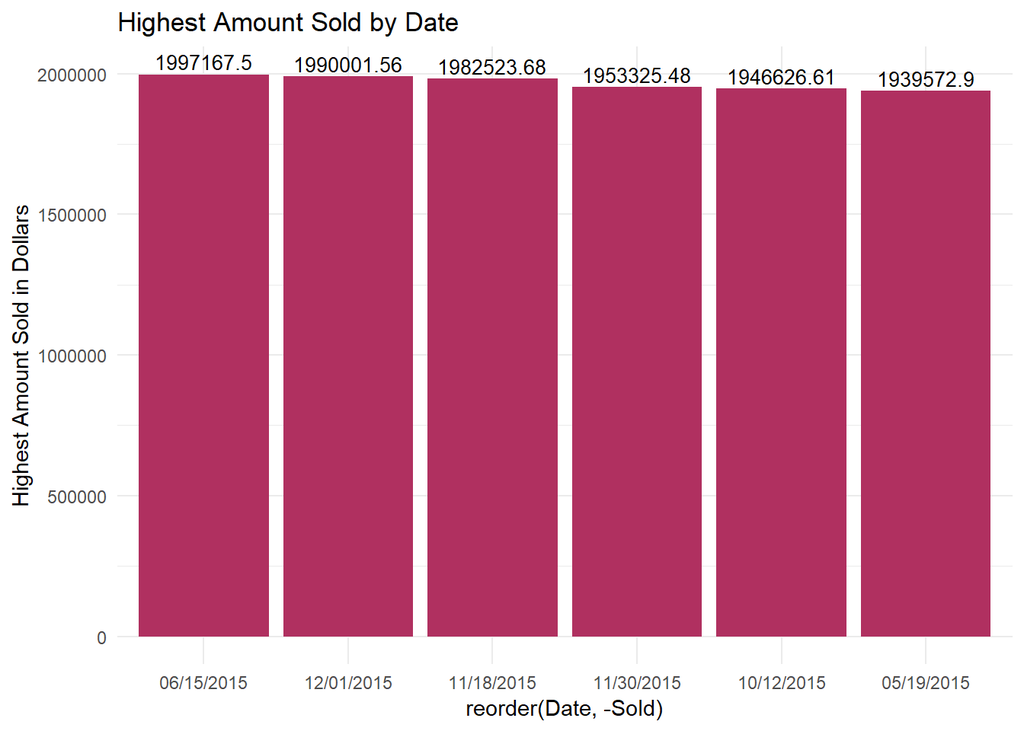

```r
ggplot(data=dateSale, aes(x=reorder(Date, -Sold), y=Sold)) +
  ylab("Highest Amount Sold in Dollars")+
  geom_bar(stat="identity", fill="maroon")+
  geom_text(aes(label=Sold), vjust=-0.3, size=3.5)+
  ggtitle("Highest Amount Sold by Date") +
  theme_minimal()
```

## _________________________________________________________________

# What Dates Sold the Least

```r
dateSaleL <- df %>%
  group_by(Date) %>%
  summarise(Sold = sum(Sale..Dollars.))
dateSaleL <- dateSaleL[order(dateSaleL$Sold, decreasing = FALSE), ]
dateSaleL <- head(dateSaleL)
```

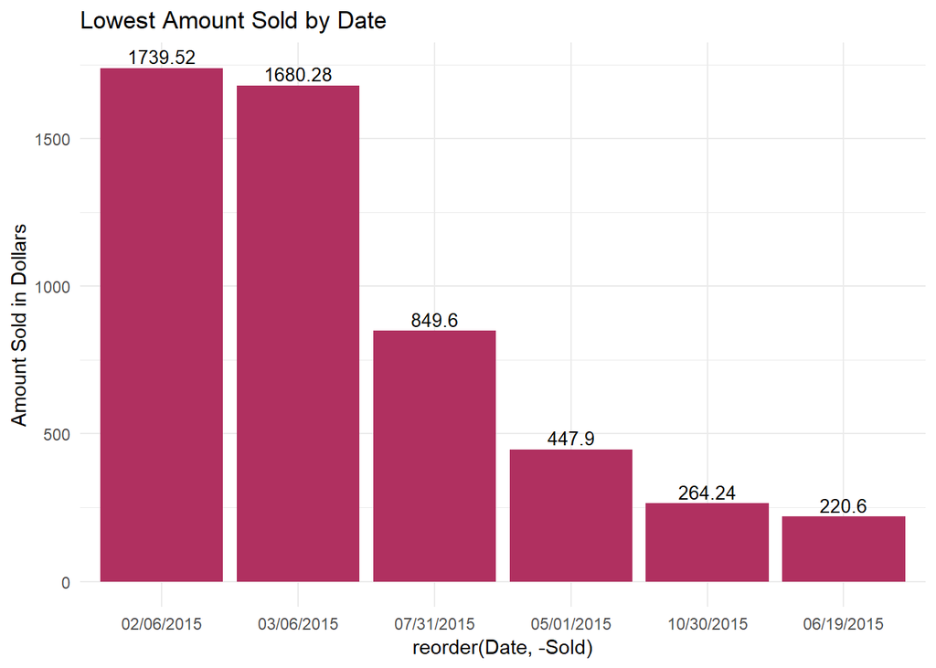

```r
ggplot(data=dateSaleL, aes(x=reorder(Date, -Sold), y=Sold)) +
  ylab("Amount Sold in Dollars")+
  geom_bar(stat="identity", fill="maroon")+
  geom_text(aes(label=Sold), vjust=-0.3, size=3.5)+
  ggtitle("Lowest Amount Sold by Date") +
  theme_minimal()
```

On the opposite side of the spectrum we have the dates that made the least amount of money in sales. Starting from the lowest we have the 19th of June, 30th of October, 1st of May, 31st of July, 6th of March, and 6th of Febuary. These dates are suspiciously low which could indicate issues with the data set especially for certain dates like the 30th of october which is the day before halloween. I would expect dates such as this to have realatively high sales.

## _________________________________________________________________

# Correlation between time of year and amount sold

```r
timeSold <- df %>%
  group_by(Date) %>%
  summarise(Num.Bottles = sum(Bottles.Sold))
timeSold <- timeSold[order(timeSold$Date, decreasing = TRUE), ]
```

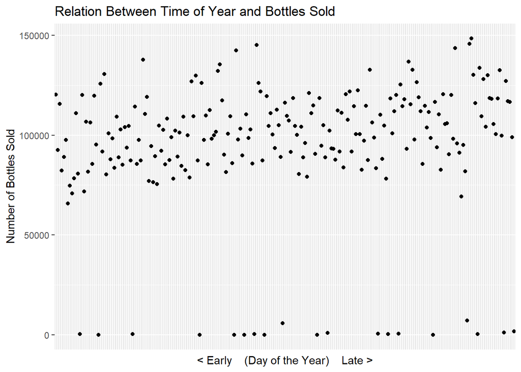

```r
ggplot(timeSold, aes(x=Date, y=Num.Bottles)) +
  xlab("< Early    (Day of the Year)    Late >")+
  ylab("Number of Bottles Sold")+
  geom_point()+
  ggtitle("Relation Between Time of Year and Bottles Sold") +
  theme( axis.text.x=element_blank(),
        axis.ticks.x=element_blank())+
  geom_smooth(method=lm)
```

This graph represents the relationship between the Date(time of year) and the number of bottles sold. Off the bat there are some immediate outliers that pop up at the bottom of the graph. These outliers are most likely days whose data was entered incorrectly as only selling around 1 or so bottles. We know that this can’t be zero since we already checked for that. This would explain why the previous bar chart had such low numbers.

If we ignore these outliers you can see that the remainder of the the data sits mostly between 75,000 and 125,000 bottles sold. I would say this is a linear relationship that is mostly constant with a few days that are significantly higher or lower that the average around 100,000.

## _________________________________________________________________

# What item made the most money

```r
itemSale <- df %>%
  group_by(Item.Description) %>%
  summarise(Sold = sum(Sale..Dollars.))
itemSale <- itemSale[order(itemSale$Sold, decreasing = TRUE), ]
itemSale <- head(itemSale)
```

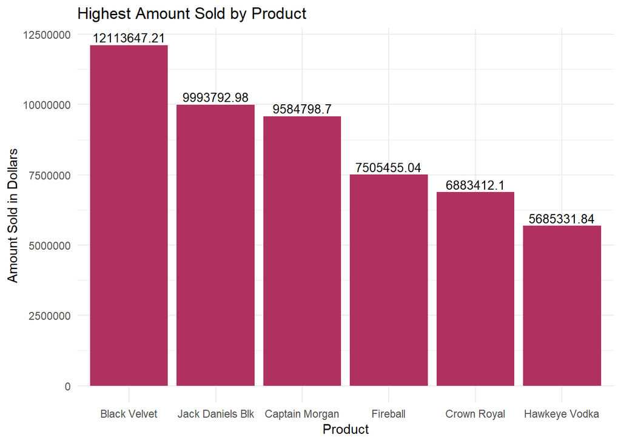

```r
ggplot(data=itemSale, aes(x=reorder(Item.Description, -Sold), y=Sold)) +
  xlab("Product")+
  ylab("Amount Sold in Dollars")+
  geom_bar(stat="identity", fill="maroon")+
  geom_text(aes(label=Sold), vjust=-0.3, size=3.5)+
  ggtitle("Highest Amount Sold by Product") +
  scale_x_discrete(labels = c("Black Velvet" = "Black Velvet", "Captain Morgan Spiced Rum" = "Captain Morgan", "Crown Royal Canadian Whisky" = "Crown Royal", "Fireball Cinnamon Whiskey" = "Fireball", "Hawkeye Vodka" = "Hawkeye Vodka", "Jack Daniels Old #7 Black Lbl" = "Jack Daniels Blk"))+
  theme_minimal()
```

This barchart shows us the top six items based on the amount of money they brought in. According to this graph Black Velvet brought in the most money in Iowa in the year 2015. This probably means its the most popular, but its possible its just exceptionaly expensive. This will have to be uncovered in another graph. Continuing down the list we have Jack Daniels Black Label, Captain Morgan Spiced Rum, Fireball Cinnamon Whiskey, Crown Royal Canadian Whisky, and Hawkeye Vodka.

## _________________________________________________________________

# What item made the least money

```r
itemSaleL <- df %>%
  group_by(Item.Description) %>%
  summarise(Sold = sum(Sale..Dollars.))
itemSaleL <- itemSaleL[order(itemSaleL$Sold, decreasing = FALSE), ]
itemSaleL <- head(itemSaleL)
```

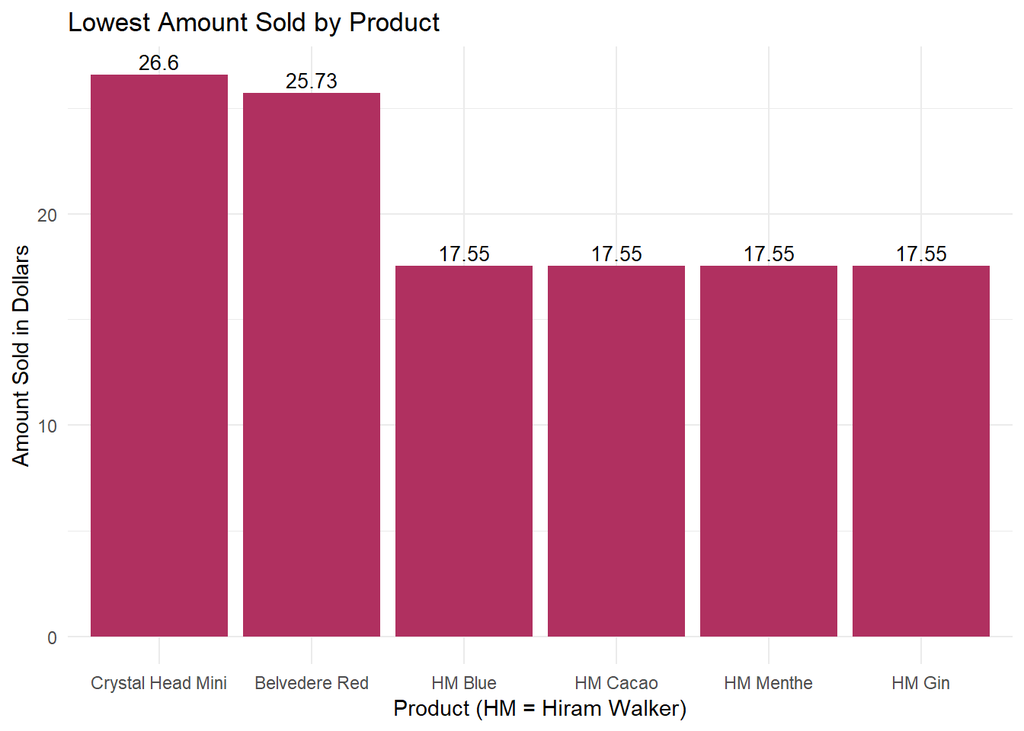

```r
ggplot(data=itemSaleL, aes(x=reorder(Item.Description, -Sold), y=Sold)) +
  xlab("Product (HM = Hiram Walker)")+
  ylab("Amount Sold in Dollars")+
  geom_bar(stat="identity", fill="maroon")+
  geom_text(aes(label=Sold), vjust=-0.3, size=3.5)+
  ggtitle("Lowest Amount Sold by Product") +
  scale_x_discrete(labels = c("Belvedere Red" = "Belvedere Red", "Crystal Head Vodka Mini" = "Crystal Head Mini", "Hiram Walker Blue Curacao 3pak" = "HM Blue", "Hiram Walker Creme De Cacao White 3pak" = "HM Cacao", "Hiram Walker Creme De Menthe White 3 Pak" = "HM Menthe", "Hiram Walker Sloe Gin 3-Pak" = "HM Gin"))+
  theme_minimal()
```

This graph shows the opposite end of the graph with the six products that brought in the least amount of money. According to this graph all of these products only sold 1 for the entire year and brought in the amount it costs to buy 1. This is most likely a mistake in the dataset, but it can’t be ruled out that the state of Iowa just hates these products.

## _________________________________________________________________

# What item was the most popular

```r
itemPop <- df %>%
  group_by(Item.Description) %>%
  summarise(Num.Bottles = sum(Bottles.Sold))
itemPop <- itemPop[order(itemPop$Num.Bottles, decreasing = TRUE), ]
itemPop <- head(itemPop)
```

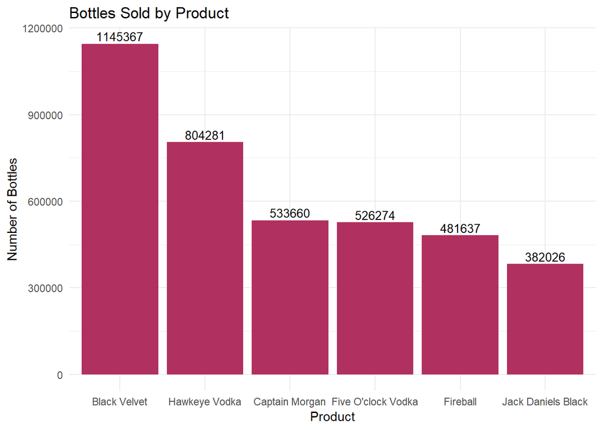

```r
ggplot(data=itemPop, aes(x=reorder(Item.Description, -Num.Bottles), y=Num.Bottles)) +
  xlab("Product")+
  ylab("Number of Bottles")+
  geom_bar(stat="identity", fill="maroon")+
  geom_text(aes(label=Num.Bottles), vjust=-0.3, size=3.5)+
  ggtitle("Bottles Sold by Product") +
  scale_x_discrete(labels = c("Black Velvet" = "Black Velvet", "Captain Morgan Spiced Rum" = "Captain Morgan", "Five O'clock Vodka" = "Five O'clock Vodka", "Fireball Cinnamon Whiskey" = "Fireball", "Hawkeye Vodka" = "Hawkeye Vodka", "Jack Daniels Old #7 Black Lbl" = "Jack Daniels Black"))+
  theme_minimal()
```

This graph is very similar to the Highest Amount Sold by Product, but instead of dealing with dollars we are looking at the physical bottles sold. You would expect this graph to be identical to that one, but it’s not. This because we are dealing with the bottles not prices, so these products that didn’t appear earlier are most likely very cheap so they can move more bottles and bring in less money. Starting off we have Black Velvet which is still 1st with 1145367 bottles sold. Then we have Hawkeye Vodka taking 2nd instead of 6th. Captain Morgan is still 3rd followed by a new prodcut Five O’clock Vodka in 4th. Finally we have Fireball and Jack Daniels in 5th and 6th instead of 4th and 2nd.

## _________________________________________________________________

# Compare cities to total bottles

```r
citySales <- df %>%
  group_by(City) %>%
  summarise(Num.Bottles = sum(Bottles.Sold))
citySales <- citySales[order(citySales$Num.Bottles, decreasing = TRUE), ]
citySales <- head(citySales)
```

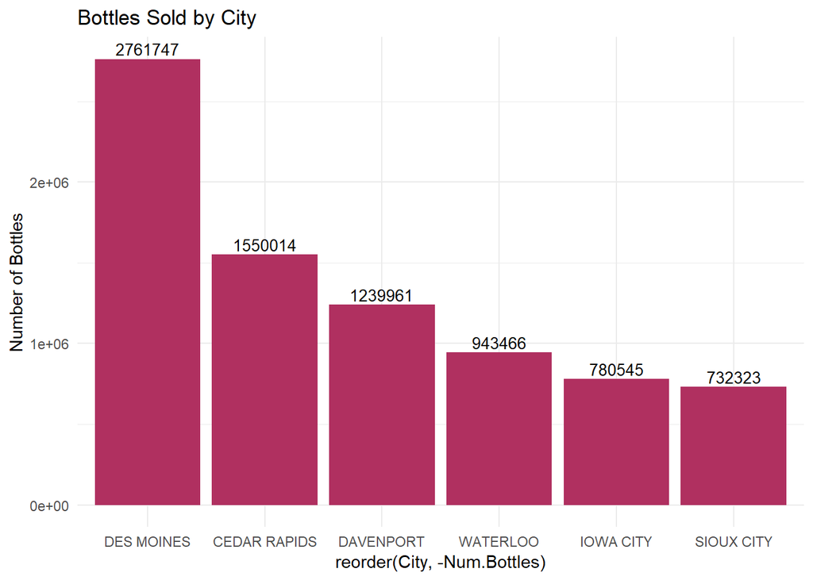

```r
ggplot(data=citySales, aes(x=reorder(City, -Num.Bottles), y=Num.Bottles)) +
  ylab("Number of Bottles")+
  geom_bar(stat="identity", fill="maroon")+
  geom_text(aes(label=Num.Bottles), vjust=-0.3, size=3.5)+
  ggtitle("Bottles Sold by City") +
  theme_minimal()
```

This graph shows us which cities sold the highest number of bottles. This graph is no suprise since the six cities with highest amount of bottles sold are also the six highest in terms of population. What is interesting is that Siox City has less liqouri purchased than both Iowa City and Waterloo. Waterloo has 15,000 less people than Sioux City yet there were 211,000 more bottles of liqour purchased that year. This could be because of a number of factors such as location, culture, and so on.

Six Largest Cities in Iowa(by population) 1.) Des Moines(217,521) 2.) Cedar Rapids(132,228) 3.) Davenport(102,320) 4.) Sioux City(82,514) 5.) Iowa City(75,798) 6.) Waterloo(67,587)

## _________________________________________________________________

# Compare cities to total volume

```r
cityVol <- df %>%
  group_by(City) %>%
  summarise(Volume.Gallons = sum(Volume.Sold..Gallons.))
cityVol <- cityVol[order(cityVol$Volume.Gallons, decreasing = TRUE), ]
cityVol <- head(cityVol)
```

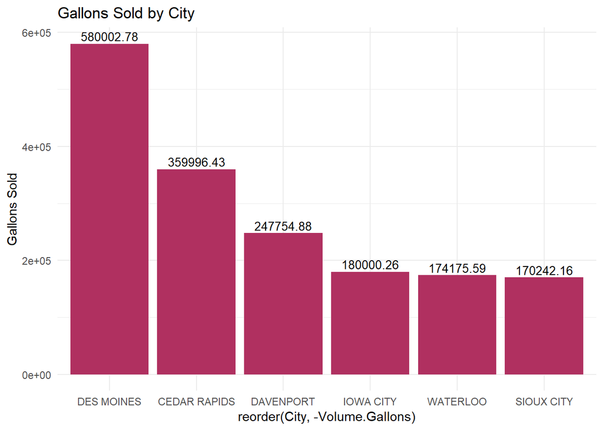

```r
ggplot(data=cityVol, aes(x=reorder(City, -Volume.Gallons), y=Volume.Gallons)) +
  ylab("Gallons Sold")+
  geom_bar(stat="identity", fill="maroon")+
  geom_text(aes(label=Volume.Gallons), vjust=-0.3, size=3.5)+
  ggtitle("Gallons Sold by City") +
  theme_minimal()
```

This graph measures the total gallons worth of liqour sold these cities. It is faily similar to the bottles graph except for the last three. There is a significantly smaller gap between them than there was in the previous graph. This could be because cities such as Waterloo were buying more bottles, but they were in much smaller sizes.

## _________________________________________________________________

# Compare months and Bottles

```r
monthBot <- df %>%
  group_by(Month) %>%
  summarise(Num.Bottles = sum(Bottles.Sold))
monthBot <- monthBot[order(monthBot$Num.Bottles, decreasing = TRUE), ]
```

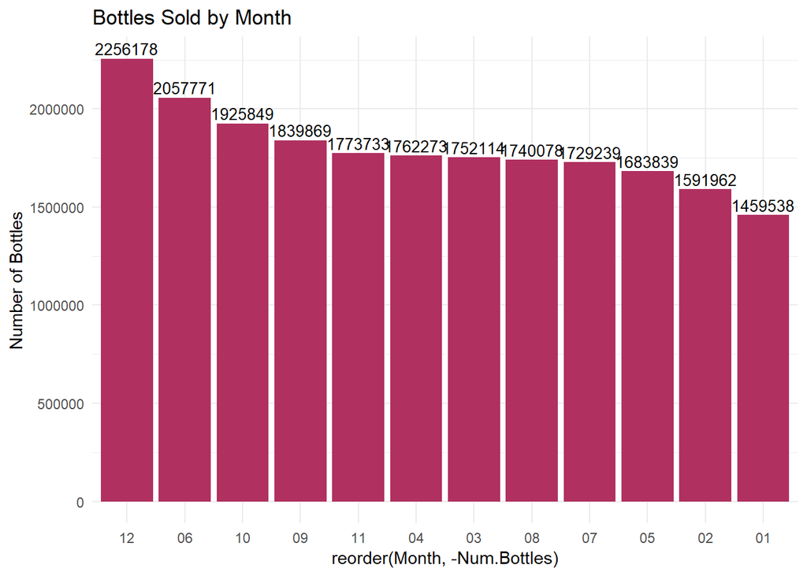

```r
ggplot(data=monthBot, aes(x=reorder(Month, -Num.Bottles), y=Num.Bottles)) +
  ylab("Number of Bottles")+
  geom_bar(stat="identity", fill="maroon")+
  geom_text(aes(label=Num.Bottles), vjust=-0.3, size=3.5)+
  ggtitle("Bottles Sold by Month") +
  theme_minimal()
```

This graph shows the amount of bottles sold per each month of 2015. According to this graph December and June sold a noticably larger amount of bottles. This makes sense since liquor sales would be expected to rise around the holiday season and the beginning of summer when people are spending a larger amount of time partying. January seems to be noticably lower than other months which could be do to new years resolutions or people staying in more.

## _________________________________________________________________

# Compare months and volume in Gallons

```r
monthGal <- df %>%
  group_by(Month) %>%
  summarise(Volume.Gallons = sum(Volume.Sold..Gallons.))
monthGal <- monthGal[order(monthGal$Volume.Gallons, decreasing = TRUE), ]
```

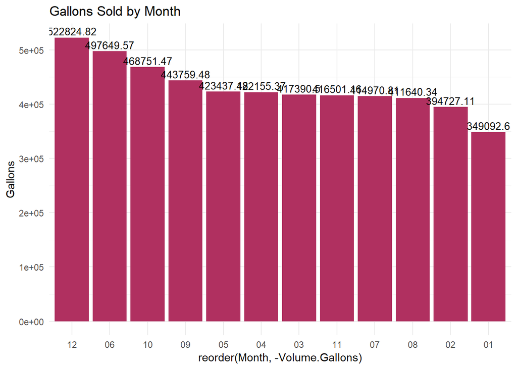

```r
ggplot(data=monthGal, aes(x=reorder(Month, -Volume.Gallons), y=Volume.Gallons)) +
  ylab("Gallons")+
  geom_bar(stat="identity", fill="maroon")+
  geom_text(aes(label=Volume.Gallons), vjust=-0.3, size=3.5)+
  ggtitle("Gallons Sold by Month") +
  theme_minimal()
```

Finnaly we have a table mimicking the last one, but in gallons instead of total bottles. There are some columns that have shifted up or down slightly, but there are not notable differences between the two.

## R Code Milestone 3

## _________________________________________________________________

# Edit Variables

```r
df <- na.omit(df)
```

```r
df$State.Bottle.Retail <- as.numeric(df$State.Bottle.Retail)
df$Bottles.Sold <- as.numeric(df$Bottles.Sold)
df$Bottle.Volume..ml. <- as.numeric(df$Bottle.Volume..ml.)
df$State.Bottle.Cost <- as.numeric(df$State.Bottle.Cost)
df$Sale..Dollars. <- as.numeric(df$Sale..Dollars.)
df$Volume.Sold..Gallons. <- as.numeric(df$Volume.Sold..Gallons.)
```

# Covariance between the selling price of bottles and bottles sold

```r
cor(df$State.Bottle.Retail,df$Bottles.Sold)
```

```
## [1] -0.01150954
```

# Covariance between the state cost for a bottle and the size of the bottle

```r
cor(df$Bottle.Volume..ml.,df$State.Bottle.Cost)
```

```
## [1] -0.01187453
```

# Covariance between the total sale and volume sold in gallons

```r
cor(df$Sale..Dollars.,df$Volume.Sold..Gallons.)
```

```
## [1] 0.840998
```

# Regress bottle retail on bottles sold

```r
model1 <- lm(Bottles.Sold ~ State.Bottle.Retail, data = df)
```

```r
stargazer(model1, type = "text", star.cutoffs = c(0.05, 0.01, 0.001),
          title="Linear Regression", digits=4)
```

```
##
## Linear Regression
## =================================================
##                          Dependent variable:
##                     -----------------------------
##                             Bottles.Sold
## -------------------------------------------------
## State.Bottle.Retail          -0.0003***
##                               (0.00002)
##
## Constant                     10.2258***
##                               (0.0261)
##
## -------------------------------------------------
## Observations                  2,184,483
## R2                             0.0001
## Adjusted R2                    0.0001
## Residual Std. Error    23.6921 (df = 2184481)
## F Statistic         289.4154*** (df = 1; 2184481)
## =================================================
## Note:               *p<0.05; **p<0.01; ***p<0.001
```

The relationship between Bottles sold and the retail price is statistically significant.

## _________________________________________________________________

# Regress cost of a bottles on the bottle size

```r
model2 <- lm(State.Bottle.Cost ~ Bottle.Volume..ml., data = df)
```

```r
stargazer(model2, type = "text", star.cutoffs = c(0.05, 0.01, 0.001),
          title="Multiple Linear Regression", digits=4)
```

```
##
## Multiple Linear Regression
## =================================================
##                          Dependent variable:
##                     -----------------------------
##                           State.Bottle.Cost
## -------------------------------------------------
## Bottle.Volume..ml.           -0.0208***
##                               (0.0012)
##
## Constant                    1,560.1770***
##                               (1.2608)
##
## -------------------------------------------------
## Observations                  2,184,483
## R2                             0.0001
## Adjusted R2                    0.0001
## Residual Std. Error    914.7977 (df = 2184481)
## F Statistic         308.0649*** (df = 1; 2184481)
## =================================================
## Note:               *p<0.05; **p<0.01; ***p<0.001
```

The relationship between the cost of bottles through the state and the size of the bottle is statistically significant.

## _________________________________________________________________

# Regress total sale on volume sold

```r
model3 <- lm(Sale..Dollars. ~ Volume.Sold..Gallons., data = df)
```

```r
stargazer(model3, type = "text", star.cutoffs = c(0.05, 0.01, 0.001),
          title="Multiple Linear Regression", digits=4)
```

```
##
## Multiple Linear Regression
## =========================================================
##                               Dependent variable:
##                       -----------------------------------
##                                 Sale..Dollars.
## ---------------------------------------------------------
## Volume.Sold..Gallons.             45.5329***
##                                    (0.0198)
##
## Constant                          22.1269***
##                                    (0.1557)
##
## ---------------------------------------------------------
## Observations                       2,184,483
## R2                                  0.7073
## Adjusted R2                         0.7073
## Residual Std. Error         219.3760 (df = 2184481)
## F Statistic           5,278,157.0000*** (df = 1; 2184481)
## =========================================================
## Note:                       *p<0.05; **p<0.01; ***p<0.001
```

The relationship between the amount of a sale and the volume sold in gallons is also significanly significant.